# hw1_Evans

Tessa Devereaux Evans

21 February 2018

question 1

```r
democracy <- read.csv("democracy.csv", stringsAsFactors = FALSE, na.strings=".")
```

question 2

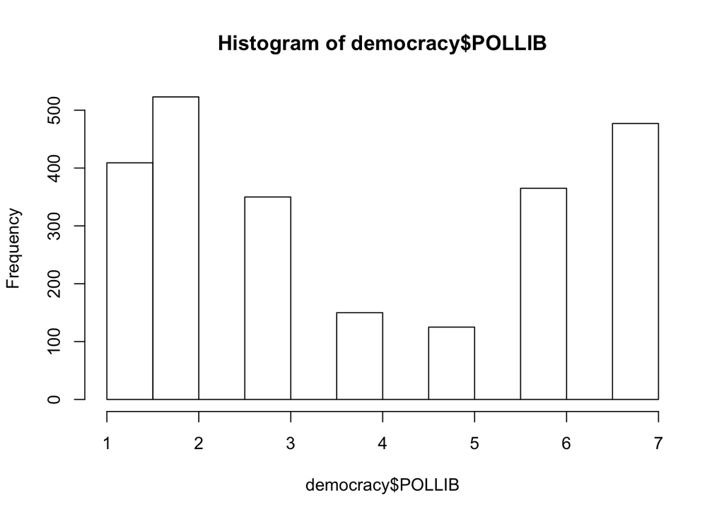

```r
#Section 2 - Initial data exploration
hist(democracy$POLLIB)
```

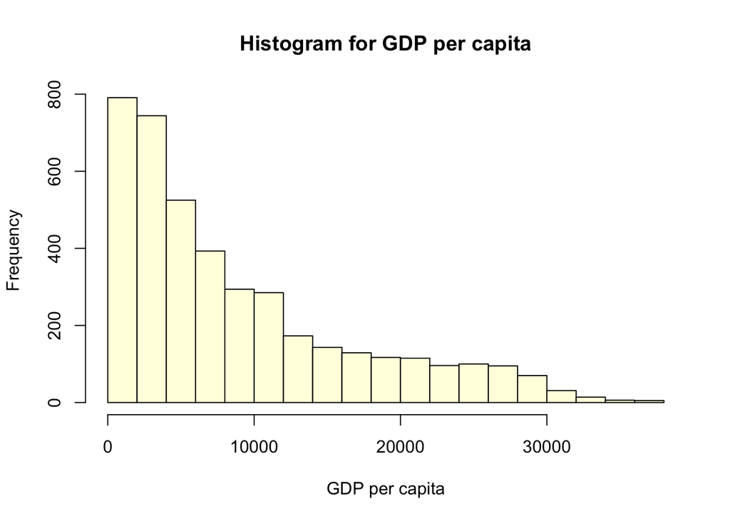

```r
hist(democracy$GDPW,
     main="Histogram for GDP per capita",
     xlab="GDP per capita",
     border="black",
     col="light yellow")
```

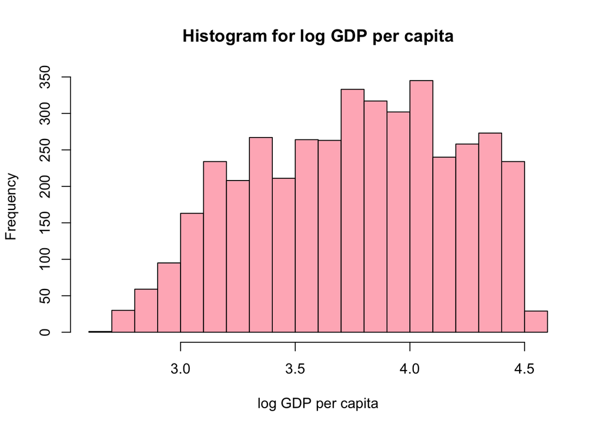

```r
hist (log10(democracy$GDPW),
     main="Histogram for log GDP per capita",
     xlab="log GDP per capita",
     border="black",
     col = "light pink")
```

This histogram uses a log transformation to make a skewed distribution less skewed. This can be valuable for making patterns in the data more interpretable and helping to meet the assumptions of inferential statistics.

Question 3

Create a scatterplot of political liberties against GDP per capita.

When there is a lot of overlap in a scatter plot it is useful to “jitter” the points

Create a scatterplot of political liberties against log GDP per capita. Jitter the points. How is the relationship different than when GDP per capita was not logged.